# UFC_EDA

Austin Snyder

2025-02-20

## import and data overview

### First focus on mens

```r
ufc_men <- read_excel("ufc_men.xlsx")
head(ufc_men)
```

```
## # A tibble: 6 × 117
##   RedFighter     BlueFighter RedOdds BlueOdds RedExpectedValue BlueExpectedValue
##   <chr>          <chr>         <dbl>    <dbl>            <dbl>             <dbl>
## 1 Alexandre Pan… Kai Asakura    -250      215             40                 215
## 2 Shavkat Rakhm… Ian Machad…    -210      295             47.6               295
## 3 Ciryl Gane     Alexander …    -380      300             26.3               300
## 4 Bryce Mitchell Kron Gracie    -950      625             10.5               625
## 5 Nate Landwehr  Dooho Choi     -130      110             76.9               110
## 6 Dominick Reyes Anthony Sm…    -380      300             26.3               300
## # ℹ 111 more variables: Date <dttm>, Location <chr>, Country <chr>,
## #   Winner <chr>, TitleBout <lgl>, WeightClass <chr>, Gender <chr>,
## #   NumberOfRounds <dbl>, BlueCurrentLoseStreak <dbl>,
## #   BlueCurrentWinStreak <dbl>, BlueDraws <dbl>, BlueAvgSigStrLanded <dbl>,
## #   BlueAvgSigStrPct <dbl>, BlueAvgSubAtt <dbl>, BlueAvgTDLanded <dbl>,
## #   BlueAvgTDPct <dbl>, BlueLongestWinStreak <dbl>, BlueLosses <dbl>,
## #   BlueTotalRoundsFought <dbl>, BlueTotalTitleBouts <dbl>, …
```

### first challenge

- how to we divvy data: we will focus on mens data first, and use one model

## Data cleaning

### convert all categorical variables to factors

```r
unique(ufc_men$Winner)
```

```
## [1] "Red"  "Blue"
```

```r
unique(ufc_men$WeightClass)
```

```
## [1] "Flyweight"         "Welterweight"      "Heavyweight"
## [4] "Featherweight"     "Light Heavyweight" "Catch Weight"
## [7] "Lightweight"       "Bantamweight"      "Middleweight"
```

```r
unique(ufc_men$BlueStance)
```

```
## [1] "Orthodox"    "Southpaw"    "Switch"      "Open Stance"
```

```r
unique(ufc_men$RedStance)
```

```
## [1] "Orthodox"    "Southpaw"    "Switch"      "Open Stance"
```

```r
unique(ufc_men$BetterRank)
```

```
## [1] "Red"     "neither" "Blue"
```

```r
unique(ufc_men$Finish)
```

```
## [1] "SUB"        "U-DEC"      "S-DEC"      "KO/TKO"     "M-DEC"
## [6] "DQ"         NA           "Overturned"
```

```r
## fix NA values in Finish
sum(is.na(ufc_men$Finish))
```

```
## [1] 196
```

```r
ufc_men$Finish[is.na(ufc_men$Finish)] <- "Unknown"
```

- there were 196 NA finishes, I replaced them with unknown

```r
## remove overturned results
ufc_men <- ufc_men[ufc_men$Finish != "Overturned", ]
```

- there were 8 overturned results, I removed them

```r
## convert to factors
ufc_men$Winner <- as.factor(ufc_men$Winner)
ufc_men$WeightClass <- factor(ufc_men$WeightClass, levels = c("Flyweight", "Bantamweight", "Featherweight",
                                                               "Lightweight", "Welterweight", "Middleweight",
                                                               "Light Heavyweight", "Heavyweight", "Catch Weight"))

ufc_men$BlueStance <- as.factor(trimws(ufc_men$BlueStance))
ufc_men$BetterRank <- as.factor(ufc_men$BetterRank)
ufc_men$Finish <- as.factor(trimws(ufc_men$Finish))
```

## EDA

```r
str(ufc_men)
```

```
## tibble [5,725 × 117] (S3: tbl_df/tbl/data.frame)
##  $ RedFighter                 : chr [1:5725] "Alexandre Pantoja" "Shavkat Rakhmonov" "Ciryl Gane" "Bryce Mitchell" ...
##  $ BlueFighter                : chr [1:5725] "Kai Asakura" "Ian Machado Garry" "Alexander Volkov" "Kron Gracie" ...
##  $ RedOdds                    : num [1:5725] -250 -210 -380 -950 -130 -380 -650 -238 150 -112 ...
##  $ BlueOdds                   : num [1:5725] 215 295 300 625 110 300 -162 195 -180 -108 ...
##  $ RedExpectedValue           : num [1:5725] 40 47.6 26.3 10.5 76.9 ...
##  $ BlueExpectedValue          : num [1:5725] 215 295 300 625 110 ...
##  $ Date                       : POSIXct[1:5725], format: "2024-12-07" "2024-12-07" ...
##  $ Location                   : chr [1:5725] "Las Vegas, Nevada, USA" "Las Vegas, Nevada, USA" "Las Vegas, Nevada, USA" "Las Vegas, Nevada, USA" ...
##  $ Country                    : chr [1:5725] "USA" "USA" "USA" "USA" ...
##  $ Winner                     : Factor w/ 2 levels "Blue","Red": 2 2 2 2 1 2 2 2 1 1 ...
##  $ TitleBout                  : logi [1:5725] TRUE FALSE FALSE FALSE FALSE FALSE ...
##  $ WeightClass                : Factor w/ 9 levels "Flyweight","Bantamweight",..: 1 5 8 3 3 7 5 3 5 9 ...
##  $ Gender                     : chr [1:5725] "MALE" "MALE" "MALE" "MALE" ...
##  $ NumberOfRounds             : num [1:5725] 5 3 3 3 3 3 3 3 3 3 ...
```

[output cut: 86 more lines]

### Wins by Weight Class

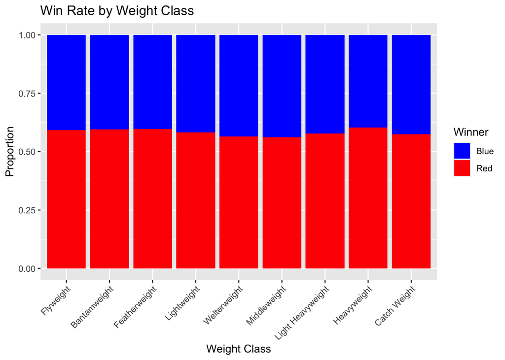

```r
ggplot(ufc_men, aes(x = WeightClass, fill = Winner)) +
  geom_bar(position = "fill") +
  scale_fill_manual(values = c("Red" = "red", "Blue" = "blue")) +  # Ensure correct colors
  labs(title = "Win Rate by Weight Class", y = "Proportion", x = "Weight Class", fill = "Winner") +
  theme(axis.text.x = element_text(angle = 45, hjust = 1))
```

- Win rate by weight class is pretty evenly distributed among the weight classes, red fighters seem to win more often across all weight classes.

### Win rate by odds and expected value

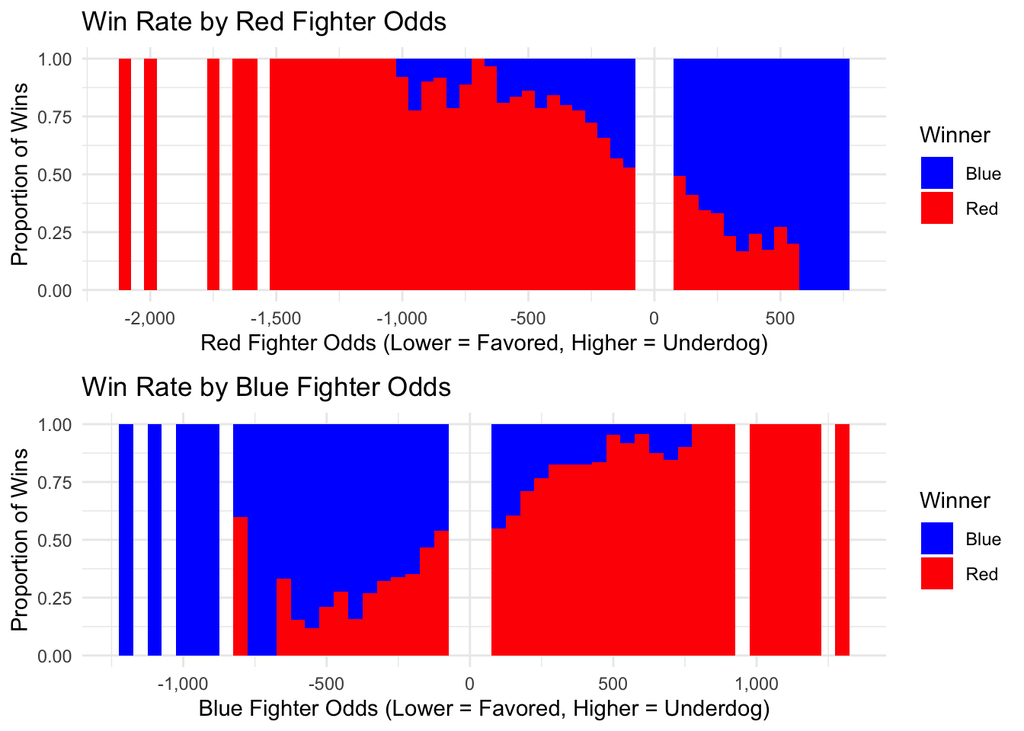

```r
# Red Fighter Odds Plot
p1 <- ggplot(ufc_men, aes(x = RedOdds, fill = Winner)) +
  geom_histogram(binwidth = 50, position = "fill") +
  scale_fill_manual(values = c("Red" = "red", "Blue" = "blue")) +
  scale_x_continuous(breaks = seq(-2000, 1000, 500), labels = scales::comma) +
  labs(title = "Win Rate by Red Fighter Odds",
       x = "Red Fighter Odds (Lower = Favored, Higher = Underdog)",
       y = "Proportion of Wins",
       fill = "Winner") +
  theme_minimal()

# Blue Fighter Odds Plot
p2 <- ggplot(ufc_men, aes(x = BlueOdds, fill = Winner)) +
  geom_histogram(binwidth = 50, position = "fill") +
  scale_fill_manual(values = c("Red" = "red", "Blue" = "blue")) +
  scale_x_continuous(breaks = seq(-2000, 1000, 500), labels = scales::comma) +
  labs(title = "Win Rate by Blue Fighter Odds",
       x = "Blue Fighter Odds (Lower = Favored, Higher = Underdog)",
       y = "Proportion of Wins",
       fill = "Winner") +
  theme_minimal()

# Print both graphs underneath each other
grid.arrange(p1, p2, ncol = 1)
```

Odds seem to be a very strong predictor of the winner. As. expected, negative odds means the fighter is favored to win and positive odds means the fighter is the underdog. Both graphs are cut diagonaly with fluctuation in the middle where odds are closest.

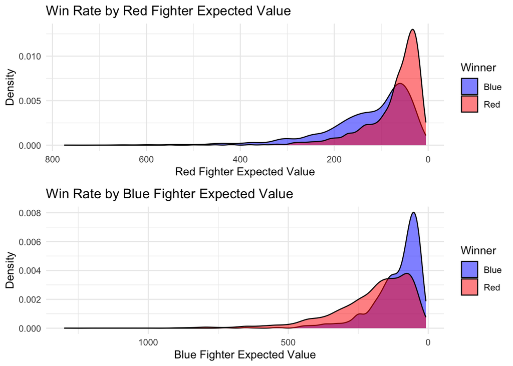

```r
# Define color mapping
fighter_colors <- c("Red" = "red", "Blue" = "blue")

# Win Rate by Red Fighter Expected Value
p3 <- ggplot(ufc_men, aes(x = RedExpectedValue, fill = Winner)) +
  geom_density(alpha = 0.5) +
  scale_fill_manual(values = fighter_colors) +
  scale_x_reverse() +  # Reverse axis for correct interpretation
  labs(title = "Win Rate by Red Fighter Expected Value",
       x = "Red Fighter Expected Value",
       y = "Density", fill = "Winner") +
  theme_minimal()

# Win Rate by Blue Fighter Expected Value
p4 <- ggplot(ufc_men, aes(x = BlueExpectedValue, fill = Winner)) +
  geom_density(alpha = 0.5) +
  scale_fill_manual(values = fighter_colors) +
  scale_x_reverse() +  # Reverse axis to align betting logic
  labs(title = "Win Rate by Blue Fighter Expected Value",
       x = "Blue Fighter Expected Value",
       y = "Density", fill = "Winner") +
  theme_minimal()
grid.arrange(p3, p4, ncol = 1)
```

- Lower EV denotes a fighter is favored to win, higher EV denotes a fighter is the underdog. - For both graphs high EV is more evenly distributed beaning these fights are less predictable. - Blue EV extends further than red which makes sense given red fighters tend to win more often, so blue fighters are more likely to be the underdog.

### Odds Ratios

```r
# Compute Ratios
ufc_men$OddsRatio <- abs(ufc_men$RedOdds / ufc_men$BlueOdds)
ufc_men$EVRatio <- abs(ufc_men$RedExpectedValue / ufc_men$BlueExpectedValue)

# Log Transform (optional, prevents extreme values from dominating)
ufc_men$LogOddsRatio <- log(ufc_men$OddsRatio)
ufc_men$LogEVRatio <- log(ufc_men$EVRatio)
```

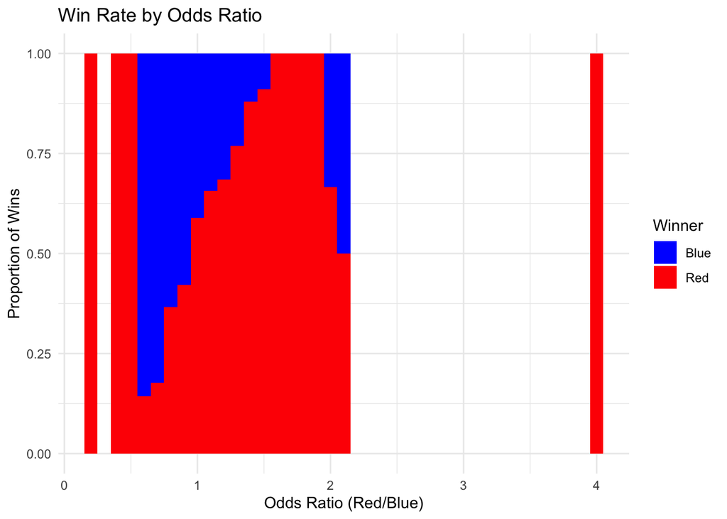

```r
ggplot(ufc_men, aes(x = OddsRatio, fill = Winner)) +
  geom_histogram(binwidth = 0.1, position = "fill") +
  scale_fill_manual(values = c("Red" = "red", "Blue" = "blue")) +
  labs(title = "Win Rate by Odds Ratio",
       x = "Odds Ratio (Red/Blue)",
       y = "Proportion of Wins",
       fill = "Winner") +
  theme_minimal()
```

## Better rank analysis

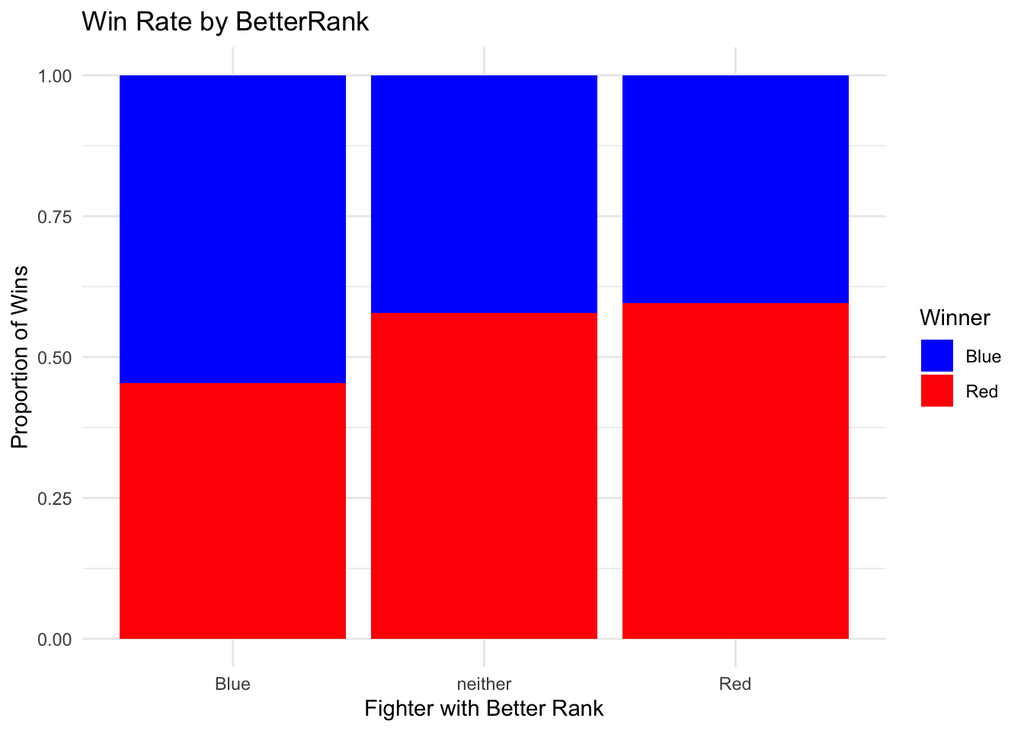

```r
ggplot(ufc_men, aes(x = BetterRank, fill = Winner)) +
  geom_bar(position = "fill") +
  scale_fill_manual(values = c("Red" = "red", "Blue" = "blue")) +
  labs(title = "Win Rate by BetterRank",
       x = "Fighter with Better Rank",
       y = "Proportion of Wins",
       fill = "Winner") +
  theme_minimal()
```

- When blue fighters have a better rank they tend to win more often at around 55 percent. - When rank is undetermined red tends to win more often at around 55 percent. - When red fighter have a better rank they tend to win more often at around 60 percent.

## Comparative Features

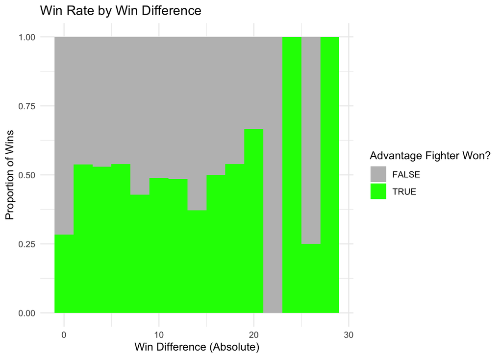

```r
ggplot(ufc_men, aes(x = abs(WinDif), fill = ((Winner == "Blue" & WinDif > 0) | (Winner == "Red" & WinDif < 0)))) +
  geom_histogram(binwidth = 2, position = "fill") +
  scale_fill_manual(values = c("TRUE" = "green", "FALSE" = "gray")) +
  labs(title = "Win Rate by Win Difference",
       x = "Win Difference (Absolute)",
       y = "Proportion of Wins",
       fill = "Advantage Fighter Won?") +
  theme_minimal()
```

- Win difference is not a strong predictor of outcome unless the difference is greater than 17 which is not common.

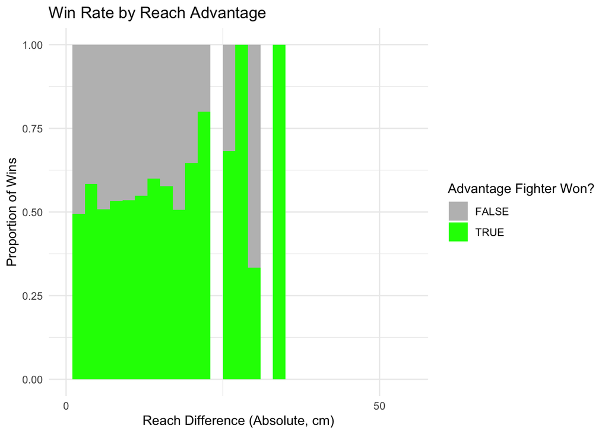

```r
ggplot(ufc_men, aes(x = abs(ReachDif), fill = ((Winner == "Blue" & ReachDif > 0) | (Winner == "Red" & ReachDif < 0)))) +
  geom_histogram(binwidth = 2, position = "fill") +
  scale_fill_manual(values = c("TRUE" = "green", "FALSE" = "gray")) +
  scale_x_continuous(breaks = seq(0, 150, by = 50), limits = c(0, 55)) +  # Restrict x-axis to 0-150 cm
  labs(title = "Win Rate by Reach Advantage",
       x = "Reach Difference (Absolute, cm)",
       y = "Proportion of Wins",
       fill = "Advantage Fighter Won?") +
  theme_minimal()
```

- reach advantage may be a solid predictor given beyond 20CM

### Age

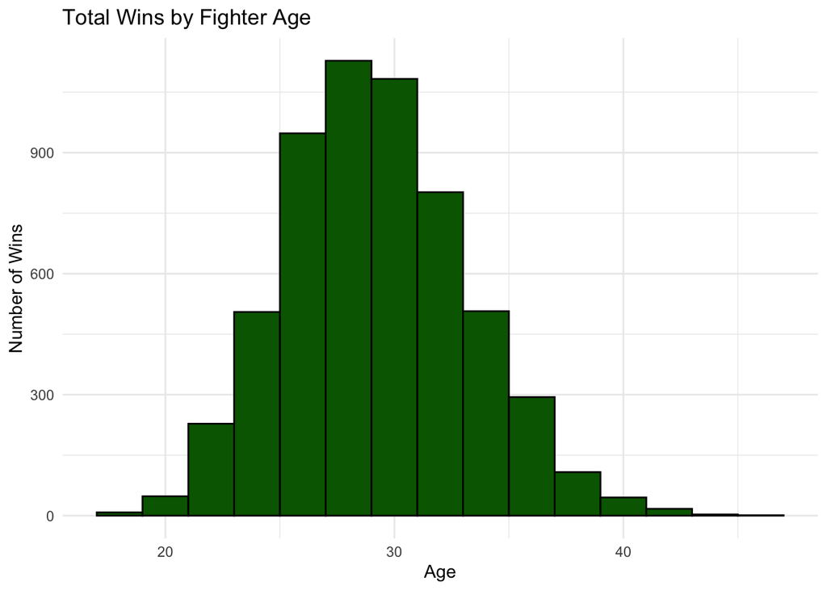

```r
# Combine both Red and Blue fighter wins into one dataset
ufc_men_wins <- data.frame(
  Age = c(ufc_men$RedAge[ufc_men$Winner == "Red"],
          ufc_men$BlueAge[ufc_men$Winner == "Blue"])
)

ggplot(ufc_men_wins, aes(x = Age)) +
  geom_histogram(binwidth = 2, fill = "darkgreen", color = "black") +
  labs(title = "Total Wins by Fighter Age",
       x = "Age",
       y = "Number of Wins") +
  theme_minimal()
```

- Wins by Age appears to be somewhat normally distributed with the mean winning age being around 30 which makes sense because this is considered to be a majority of fighters prime given fight experience.

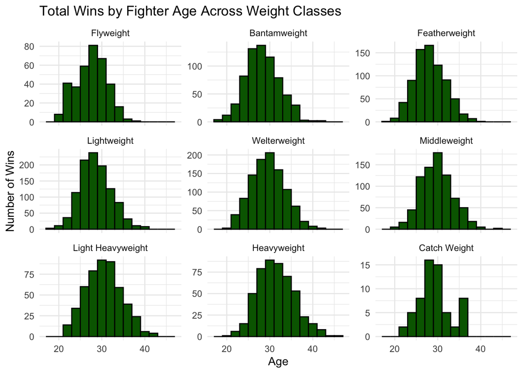

```r
# Create a data set with Winner's Age and Weight Class
ufc_men_wins <- data.frame(
  Age = c(ufc_men$RedAge[ufc_men$Winner == "Red"],
          ufc_men$BlueAge[ufc_men$Winner == "Blue"]),
  WeightClass = c(ufc_men$WeightClass[ufc_men$Winner == "Red"],
                  ufc_men$WeightClass[ufc_men$Winner == "Blue"])
)

saveRDS(ufc_men, "ufc_men_cleaned.rds")


# Plot Total Wins by Age, Faceted by Weight Class
ggplot(ufc_men_wins, aes(x = Age)) +
  geom_histogram(binwidth = 2, fill = "darkgreen", color = "black") +
  facet_wrap(~WeightClass, scales = "free_y") +  # Separate by weight class
  labs(title = "Total Wins by Fighter Age Across Weight Classes",
       x = "Age",
       y = "Number of Wins") +
  theme_minimal()
```

- This seems to hold true across weight classes, notably feather weight and light weight are slightly younger on average.

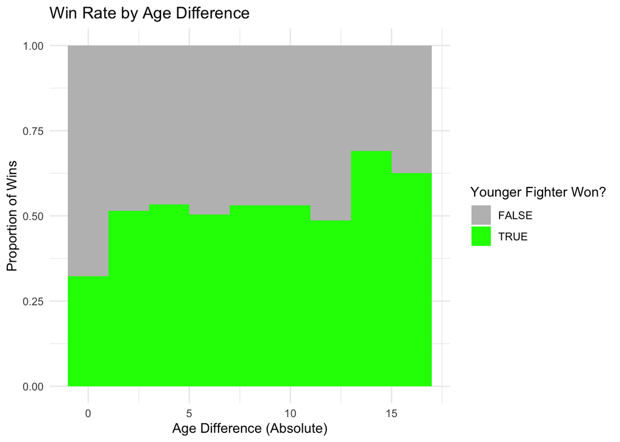

```r
library(ggplot2)

ggplot(ufc_men, aes(x = abs(AgeDif), fill = ((Winner == "Blue" & AgeDif > 0) | (Winner == "Red" & AgeDif < 0)))) +
  geom_histogram(binwidth = 2, position = "fill") +
  scale_fill_manual(values = c("TRUE" = "green", "FALSE" = "gray")) +
  labs(title = "Win Rate by Age Difference",
       x = "Age Difference (Absolute)",
       y = "Proportion of Wins",
       fill = "Younger Fighter Won?") +
  theme_minimal()
```

- Age difference is not a strong predictor of outcome unless the difference is 12 years plus younger fighters are more likely to win.

### Significant Strikes

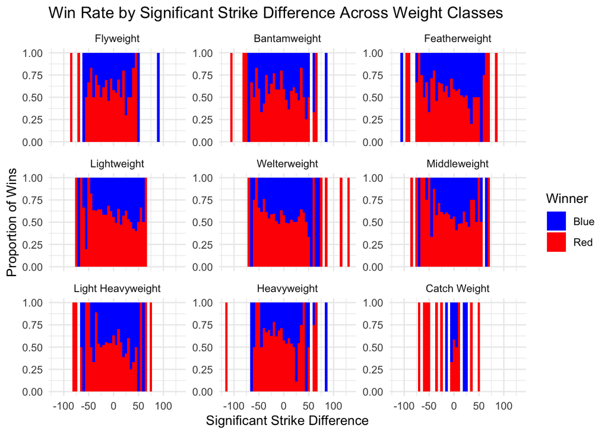

```r
ggplot(ufc_men, aes(x = SigStrDif, fill = Winner)) +
  geom_histogram(binwidth = 5, position = "fill") +
  facet_wrap(~WeightClass, scales = "free_y") +  # Separate by weight class
  scale_fill_manual(values = c("Red" = "red", "Blue" = "blue")) +
  labs(title = "Win Rate by Significant Strike Difference Across Weight Classes",
       x = "Significant Strike Difference",
       y = "Proportion of Wins",
       fill = "Winner") +
  theme_minimal()
```

-lighter Weight Classes (Bantamweight, Flyweight, Featherweight, Lightweight): More striking volume overall. Fighters with higher SigStrDif tend to win more. Striking differential seems to have a stronger impact on winning.

-Heavier Weight Classes (Middleweight, Light Heavyweight, Heavyweight): Striking differential appears less critical. More fights are won with low or even negative SigStrDif. This suggests more KO power, grappling, or lower volume exchanges are bigger factors.

-Catch Weight & Welterweight: More scattered results. Possible smaller sample size for Catch Weight makes trends less obvious. This is a common occurrence for these weight classes.

### Take Downs

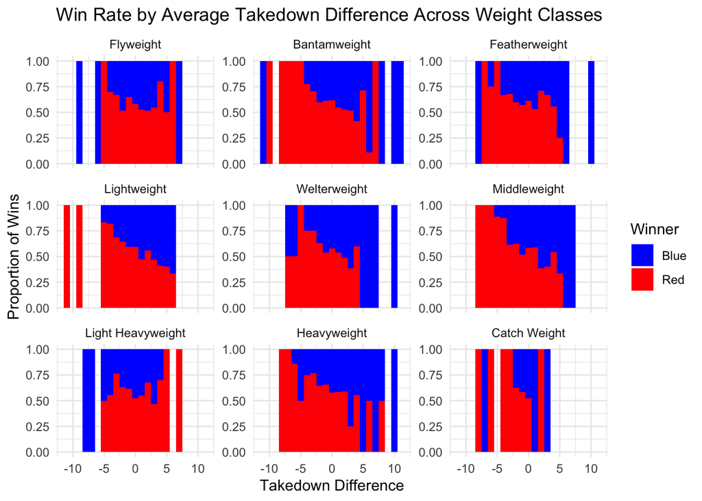

```r
ggplot(ufc_men, aes(x = AvgTDDif, fill = Winner)) +
  geom_histogram(binwidth = 1, position = "fill") +
  facet_wrap(~WeightClass, scales = "free_y") +
  scale_fill_manual(values = c("Red" = "red", "Blue" = "blue")) +
  labs(title = "Win Rate by Average Takedown Difference Across Weight Classes",
       x = "Takedown Difference",
       y = "Proportion of Wins",
       fill = "Winner") +
  theme_minimal()
```

-Takedown Difference Matters More in Heavier Divisions (Middleweight, Light Heavyweight, Heavyweight)

As AvgTDDif increases, win probability also increases. Fighters with more takedowns generally win in heavier classes. This uggests that grappling and control time are more important at higher weights.

- Lighter Weight Classes (Bantamweight, Flyweight, Featherweight, Lightweight) Less reliance on take downs suggesting striking may play a bigger role. Common for fighters to still win despite a take down disadvantage. Flyweight and Featherweight show a mixed pattern, meaning ground game isn’t always the deciding factor.

-Catch Weight & Welterweight Again, scattered results, possibly due to a smaller sample size. Welterweight follows a similar trend as middleweight but with more variability.

# KO/TKO

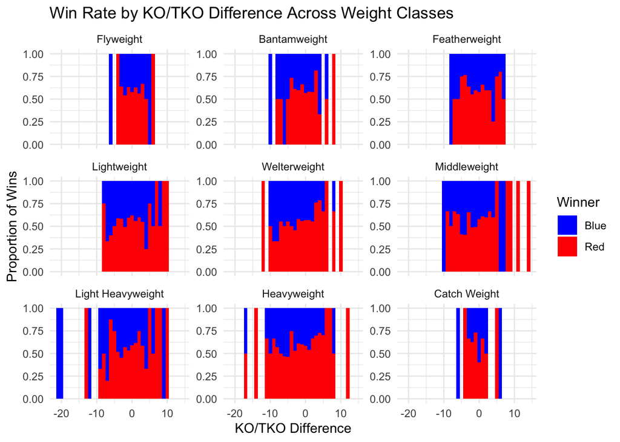

```r
ggplot(ufc_men, aes(x = KODif, fill = Winner)) +
  geom_histogram(binwidth = 1, position = "fill") +
  facet_wrap(~WeightClass, scales = "free_y") +
  scale_fill_manual(values = c("Red" = "red", "Blue" = "blue")) +
  labs(title = "Win Rate by KO/TKO Difference Across Weight Classes",
       x = "KO/TKO Difference",
       y = "Proportion of Wins",
       fill = "Winner") +
  theme_minimal()
```

- KO/TKO Difference is More Predictive in Heavier Weight Classes (Middleweight, Light Heavyweight, Heavyweight)

-KO/TKO Difference is Less Predictive in Lighter Weight Classes (Bantamweight, Flyweight, Featherweight, Lightweight)

KO power seems to matter less in lower weight classes, which aligns with expectations since these fighters rely more on speed, volume striking, and decisions. There are more mixed results, meaning that fighters can still win despite having fewer career KOs.

Featherweight and Flyweight show relatively balanced win rates, meaning knockout experience isn’t a dominant factor in these divisions.

-Catch Weight & Welterweight

Catch Weight lacks clear trends, possibly due to a small sample size.

### Submissions

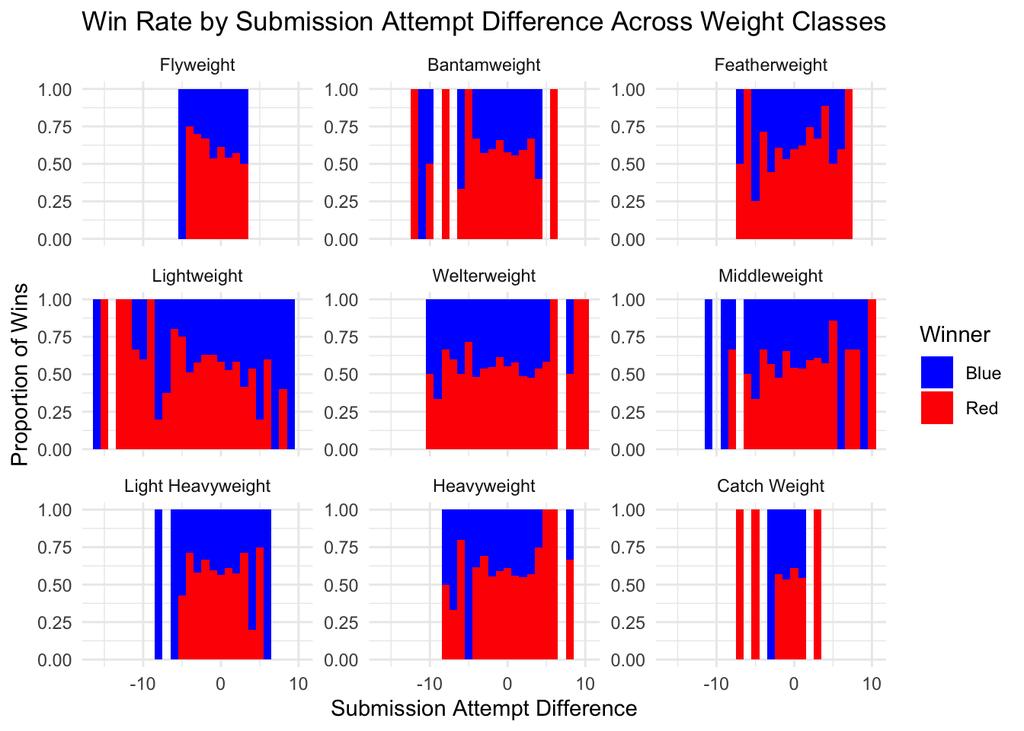

```r
ggplot(ufc_men, aes(x = SubDif, fill = Winner)) +
  geom_histogram(binwidth = 1, position = "fill") +
  facet_wrap(~WeightClass, scales = "free_y") +
  scale_fill_manual(values = c("Red" = "red", "Blue" = "blue")) +
  labs(title = "Win Rate by Submission Attempt Difference Across Weight Classes",
       x = "Submission Attempt Difference",
       y = "Proportion of Wins",
       fill = "Winner") +
  theme_minimal()
```

-submissions Are Less Predictive in Heavier Weight Classes (Middleweight, Light Heavyweight, Heavyweight) More mixed results, meaning submission attempts don’t always lead to victory. Heavyweights still win despite fewer submission attempts, indicating power striking may be more dominant. Fighters who land more takedowns (AvgTDDif) might be controlling fights instead of finishing via submission.

-Catch Weight & Welterweight Again, More scattered results, likely due to sample size issues.

## Additional Betting Odds

These are Set by Sportsbooks and Reflect Market Expectations

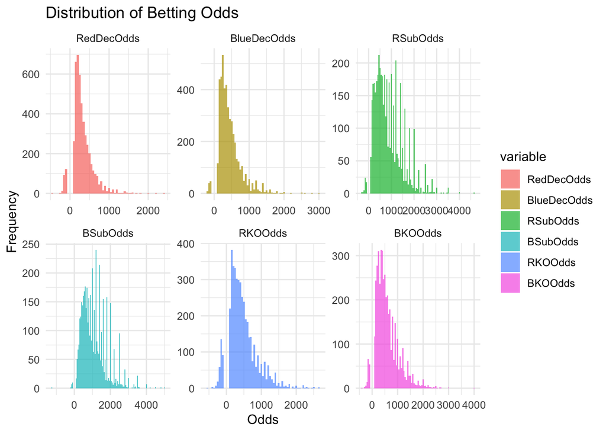

```r
# Select only betting odds columns
betting_odds <- ufc_men[, c("RedDecOdds", "BlueDecOdds", "RSubOdds", "BSubOdds", "RKOOdds", "BKOOdds")]

# Convert to long format for easier plotting
betting_odds_long <- melt(betting_odds)
# Plot distribution
ggplot(betting_odds_long, aes(x = value, fill = variable)) +
  geom_histogram(binwidth = 50, alpha = 0.7, position = "identity") +
  facet_wrap(~variable, scales = "free") +
  labs(title = "Distribution of Betting Odds", x = "Odds", y = "Frequency") +
  theme_minimal()
```

- Submission Odds (RSubOdds, BSubOdds) Much wider range, with many values above +1000. This suggests submissions are often viewed as underdog outcomes. Higher variance means sports books rarely predict subs as likely.
- KO/TKO Odds (RKOOdds, BKOOdds) More normally distributed than submissions. KO wins are expected more often than subs but less than decisions. Few extreme values compared to submission odds.

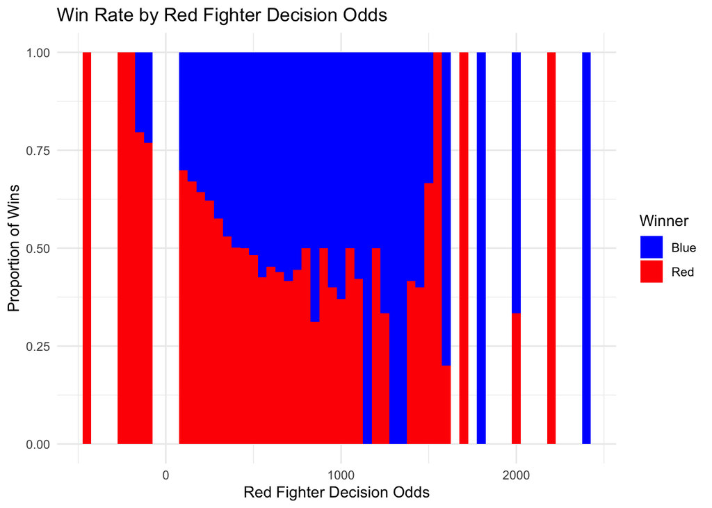

```r
ggplot(ufc_men, aes(x = RedDecOdds, fill = Winner)) +
  geom_histogram(binwidth = 50, position = "fill") +
  scale_fill_manual(values = c("Red" = "red", "Blue" = "blue")) +
  labs(title = "Win Rate by Red Fighter Decision Odds",
       x = "Red Fighter Decision Odds",
       y = "Proportion of Wins",
       fill = "Winner") +
  theme_minimal()
```

- Lower (More Favored) Decision Odds equals Higher Win Rate (obviously)

On the left side (odds closer to 0 or negative), Red wins more often. This aligns with expectations—when the market strongly favors Red to win by decision, they usually do. Higher (Less Favored) Decision Odds results in more Blue Wins Irregularities at High Odds (Extreme Values Above 1000) This might be due to smaller sample sizes.

## Odds Correlation with Outcome

```r
# Compute correlation matrix
cor(ufc_men[, c("RedDecOdds", "BlueDecOdds", "RSubOdds", "BSubOdds", "RKOOdds", "BKOOdds")],
    as.numeric(ufc_men$Winner == "Red"), use = "complete.obs")
```

```
##                   [,1]
## RedDecOdds  -0.1745153
## BlueDecOdds  0.2283873
## RSubOdds    -0.1507795
## BSubOdds     0.1751522
## RKOOdds     -0.1963483
## BKOOdds      0.2164072
```

Red Decision: -0.17, Lower decision odds or red result in a higher probability red fighter will win, Market odds are a strong predictor of the winner.

Blue Decision: .23, Higher decision odds or blue result in a higher probability red fighters will win, not common for underdogs to win by decision.

Red Submission: -0.15, Market odds are a strong predictor of the winner of red fighters via submission.

Blue Submission: 0.18, if odds predict blue to loos by submission books are generally correct.

Red KO/TKO: -0.20, Low odds for red fighters to win by KO/TKO are a strong predictor

Blue KO/TKO: 0.22, if odds are low for blue fighters to win by KO/TKO it is generally uncommon.

KO/TKO odds are the most predictive of the outcome, followed by decision odds, and then submission odds.

### Total Title Bout Difference

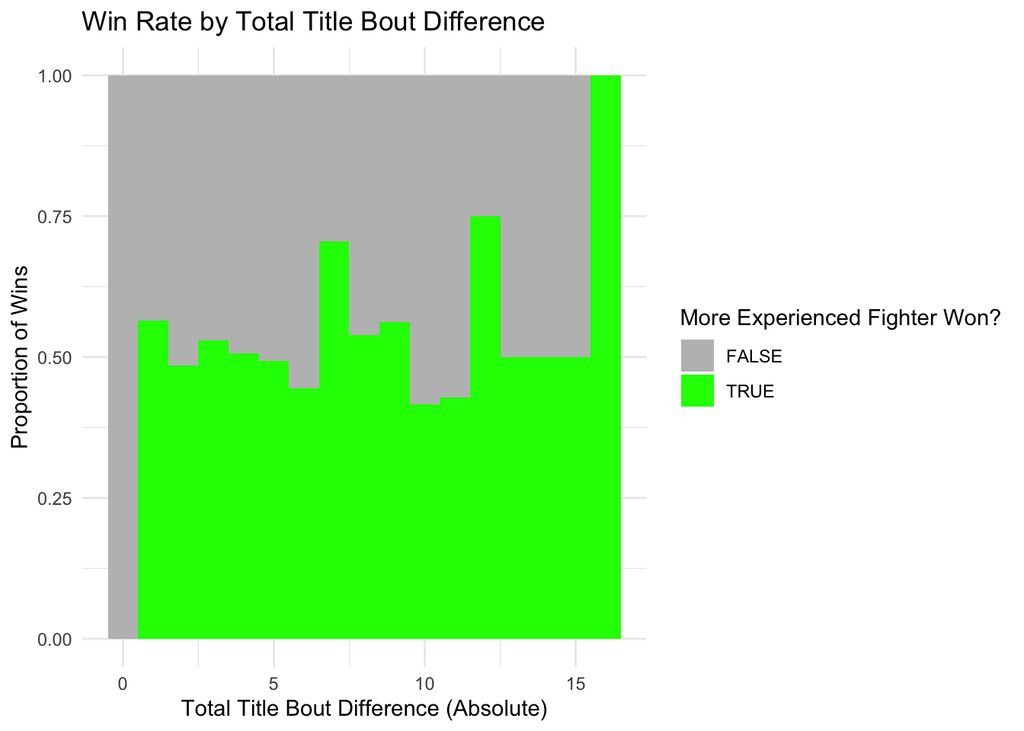

```r
ggplot(ufc_men, aes(x = abs(TotalTitleBoutDif), fill = ((Winner == "Blue" & TotalTitleBoutDif > 0) | (Winner == "Red" & TotalTitleBoutDif < 0)))) +
  geom_histogram(binwidth = 1, position = "fill") +
  scale_fill_manual(values = c("TRUE" = "green", "FALSE" = "gray")) +
  labs(title = "Win Rate by Total Title Bout Difference",
       x = "Total Title Bout Difference (Absolute)",
       y = "Proportion of Wins",
       fill = "More Experienced Fighter Won?") +
  theme_minimal()
```